# Abdelmegeed

```python
import pandas as pd
import numpy as np
import datetime as dt
```

```python
SELECTED_STATE_FIPS = 6
NORMALIZATION_FACTOR = 100000
NORMALIZATION_FLAG = False
MARKER_SIZE=5
PREFIX_PATH = '../team_work/data/'
FORECAST_IN_DAYS = 10
```

```python
from sklearn.linear_model import LinearRegression
from sklearn.preprocessing import PolynomialFeatures
from sklearn.model_selection import train_test_split
from sklearn.metrics import mean_squared_error
from math import sqrt

class MyRegressionModel:
    """
    df: should be in format <index = Datetime> <columns = state_name> <values = number of new cases/deaths>
    """
    def __init__(self, x_train, y_train, x_test, y_test, fit_type='Linear', error_type='RMSE', degree=3):
        self.degree = degree
        self.fit_type = fit_type
        self.error_type = error_type
        self.degree = degree
        x_train = x_train.reshape(-1,1)
        x_test = x_test.reshape(-1,1)
        if self.fit_type == 'Polynomial':
            poly = PolynomialFeatures(degree=self.degree)
            x_train = poly.fit_transform(x_train)
            x_test = poly.fit_transform(x_test)
        self.x_train = x_train
        self.y_train = y_train
        self.x_test = x_test
        self.y_test = y_test
        self.fit_data(x_train, y_train)
        self.test_model(x_test, y_test)

    def fit_data(self, x_train, y_train):
        pr = LinearRegression()
        x = x_train
        y = y_train
        pr.fit(x, y)
        self.model = pr


    def test_model(self, x_test, y_test):
        y_pred = self.model.predict(x_test).reshape(len(x_test))
        if self.error_type == 'RMSE':
            self.error = sqrt(abs(mean_squared_error(y_test, y_pred)))
        residuals_lr = self.y_train - self.model.predict(self.x_train)
        ci_lr = np.quantile(residuals_lr, 0.95)
        self.confidence = self.generate_confidence_interval(y_pred, ci_lr)
        print(self.confidence)

    def generate_confidence_interval(self, preds, ci):
        df = pd.DataFrame()
        df['prediction'] = preds
        if ci >= 0:
            df['upper'] = preds + ci
            df['lower'] = preds - ci
        else:
            df['upper'] = preds - ci
            df['lower'] = preds + ci
        return df

    def predict(self, x):
        if self.fit_type == 'Polynomial':
            poly = PolynomialFeatures(degree=self.degree)
            x = poly.fit_transform(x)
        return self.model.predict(x)




def get_county_population(county_name):
    df = pd.read_csv(f'{PREFIX_PATH}covid_county_population_usafacts.csv')
    df = df[df['County Name'] == county_name]
    return df['population'].values[0]

def get_state_population(state):
    """
    Returns the population of the selected state

    Args:
        state (str): State abb

    Returns:
        int: Population
    """
    population = pd.read_csv(f'{PREFIX_PATH}/covid_county_population_usafacts.csv')
    population = population.groupby('State').sum(numeric_only=True)
    return population.loc[state, 'population']
```

```python
covid_confirmed_df = pd.read_csv(f'{PREFIX_PATH}covid_confirmed_usafacts.csv')
covid_confirmed_df = covid_confirmed_df[covid_confirmed_df['countyFIPS'] != 0]
covid_confirmed_df = covid_confirmed_df[covid_confirmed_df['StateFIPS'] == SELECTED_STATE_FIPS]
```

```python
covid_deaths_df = pd.read_csv(f'{PREFIX_PATH}covid_deaths_usafacts.csv')
covid_deaths_df = covid_deaths_df[covid_deaths_df['countyFIPS'] != 0]
covid_deaths_df = covid_deaths_df[covid_deaths_df['StateFIPS'] == SELECTED_STATE_FIPS]
```

```python
selected_state_name = covid_confirmed_df['State'].iloc[0]
covid_confirmed_df = covid_confirmed_df.drop(['State', 'StateFIPS'], axis=1)
covid_deaths_df = covid_deaths_df.drop(['State', 'StateFIPS'], axis=1)
```

```python
covid_confirmed_df.head(3)
```

|  | countyFIPS | County Name | 2020-01-22 | 2020-01-23 | 2020-01-24 | 2020-01-25 | 2020-01-26 | 2020-01-27 | 2020-01-28 | 2020-01-29 | ... | 2023-01-07 | 2023-01-08 | 2023-01-09 | 2023-01-10 | 2023-01-11 | 2023-01-12 | 2023-01-13 | 2023-01-14 | 2023-01-15 | 2023-01-16 |
| --- | --- | --- | --- | --- | --- | --- | --- | --- | --- | --- | --- | --- | --- | --- | --- | --- | --- | --- | --- | --- | --- |
| 191 | 6001 | Alameda County | 4 | 4 | 4 | 5 | 5 | 5 | 5 | 5 | ... | 369865 | 369865 | 371477 | 371682 | 371847 | 371955 | 372102 | 372232 | 372305 | 372364 |
| 192 | 6003 | Alpine County | 0 | 0 | 0 | 0 | 0 | 0 | 0 | 0 | ... | 138 | 138 | 139 | 139 | 139 | 139 | 139 | 139 | 139 | 139 |
| 193 | 6005 | Amador County | 1 | 1 | 1 | 1 | 1 | 1 | 1 | 1 | ... | 10339 | 10339 | 10381 | 10386 | 10391 | 10392 | 10395 | 10396 | 10398 | 10399 |

3 rows × 1093 columns

```python
covid_deaths_df.head(3)
```

|  | countyFIPS | County Name | 2020-01-22 | 2020-01-23 | 2020-01-24 | 2020-01-25 | 2020-01-26 | 2020-01-27 | 2020-01-28 | 2020-01-29 | ... | 2023-01-07 | 2023-01-08 | 2023-01-09 | 2023-01-10 | 2023-01-11 | 2023-01-12 | 2023-01-13 | 2023-01-14 | 2023-01-15 | 2023-01-16 |
| --- | --- | --- | --- | --- | --- | --- | --- | --- | --- | --- | --- | --- | --- | --- | --- | --- | --- | --- | --- | --- | --- |
| 191 | 6001 | Alameda County | 0 | 0 | 0 | 0 | 0 | 0 | 0 | 0 | ... | 2098 | 2098 | 2125 | 2125 | 2125 | 2125 | 2125 | 2125 | 2125 | 2125 |
| 192 | 6003 | Alpine County | 0 | 0 | 0 | 0 | 0 | 0 | 0 | 0 | ... | 0 | 0 | 0 | 0 | 0 | 0 | 0 | 0 | 0 | 0 |
| 193 | 6005 | Amador County | 0 | 0 | 0 | 0 | 0 | 0 | 0 | 0 | ... | 96 | 96 | 97 | 97 | 97 | 97 | 97 | 97 | 97 | 97 |

3 rows × 1093 columns

```python
covid_county_most_cases = covid_confirmed_df.sort_values(by=str(covid_confirmed_df.columns[-1]), ascending=False)
covid_county_most_cases = covid_county_most_cases.iloc[:5]
selected_counties_most_cases_fips = covid_county_most_cases['countyFIPS'].values
selected_counties_most_cases_names = covid_county_most_cases['County Name'].values
covid_county_most_cases = covid_county_most_cases.drop(['countyFIPS', 'County Name'], axis=1)
covid_county_most_cases
```

|  | 2020-01-22 | 2020-01-23 | 2020-01-24 | 2020-01-25 | 2020-01-26 | 2020-01-27 | 2020-01-28 | 2020-01-29 | 2020-01-30 | 2020-01-31 | ... | 2023-01-07 | 2023-01-08 | 2023-01-09 | 2023-01-10 | 2023-01-11 | 2023-01-12 | 2023-01-13 | 2023-01-14 | 2023-01-15 | 2023-01-16 |
| --- | --- | --- | --- | --- | --- | --- | --- | --- | --- | --- | --- | --- | --- | --- | --- | --- | --- | --- | --- | --- | --- |
| 209 | 375 | 379 | 382 | 384 | 385 | 388 | 390 | 391 | 392 | 401 | ... | 3433929 | 3433929 | 3445989 | 3447247 | 3448295 | 3449312 | 3450050 | 3450670 | 3451023 | 3451236 |
| 227 | 0 | 0 | 0 | 0 | 0 | 0 | 0 | 0 | 0 | 0 | ... | 967383 | 967383 | 970803 | 971338 | 971759 | 972124 | 972429 | 972689 | 972860 | 973029 |
| 223 | 60 | 60 | 60 | 60 | 60 | 61 | 61 | 61 | 61 | 62 | ... | 723518 | 723518 | 726237 | 726482 | 726693 | 726875 | 727071 | 727241 | 727327 | 727396 |
| 226 | 76 | 78 | 78 | 80 | 81 | 83 | 84 | 85 | 86 | 89 | ... | 699474 | 699474 | 701753 | 701972 | 702129 | 702309 | 702439 | 702549 | 702633 | 702697 |
| 220 | 8 | 8 | 9 | 9 | 9 | 9 | 9 | 9 | 10 | 10 | ... | 697388 | 697388 | 700011 | 700318 | 700576 | 700810 | 701049 | 701257 | 701371 | 701471 |

5 rows × 1091 columns

```python
covid_county_most_deaths = covid_deaths_df.sort_values(by=str(covid_deaths_df.columns[-1]), ascending=False)
covid_county_most_deaths = covid_county_most_deaths.iloc[:5]
selected_counties_most_deaths_fips = covid_county_most_deaths['countyFIPS']
selected_counties_most_deaths_names = covid_county_most_deaths['County Name']
covid_county_most_deaths = covid_county_most_deaths.drop(['countyFIPS', 'County Name'], axis=1)
covid_county_most_deaths
```

|  | 2020-01-22 | 2020-01-23 | 2020-01-24 | 2020-01-25 | 2020-01-26 | 2020-01-27 | 2020-01-28 | 2020-01-29 | 2020-01-30 | 2020-01-31 | ... | 2023-01-07 | 2023-01-08 | 2023-01-09 | 2023-01-10 | 2023-01-11 | 2023-01-12 | 2023-01-13 | 2023-01-14 | 2023-01-15 | 2023-01-16 |
| --- | --- | --- | --- | --- | --- | --- | --- | --- | --- | --- | --- | --- | --- | --- | --- | --- | --- | --- | --- | --- | --- |
| 209 | 0 | 0 | 0 | 0 | 0 | 0 | 0 | 0 | 0 | 0 | ... | 34488 | 34488 | 34762 | 34771 | 34779 | 34783 | 34786 | 34786 | 34786 | 34786 |
| 226 | 0 | 0 | 0 | 0 | 0 | 0 | 0 | 0 | 0 | 0 | ... | 8104 | 8104 | 8115 | 8116 | 8116 | 8116 | 8116 | 8116 | 8116 | 8116 |
| 220 | 0 | 0 | 0 | 0 | 0 | 0 | 0 | 0 | 0 | 0 | ... | 7683 | 7683 | 7754 | 7754 | 7754 | 7754 | 7754 | 7754 | 7754 | 7754 |
| 223 | 0 | 0 | 0 | 0 | 0 | 0 | 0 | 0 | 0 | 0 | ... | 6714 | 6714 | 6753 | 6753 | 6753 | 6753 | 6753 | 6753 | 6753 | 6753 |
| 227 | 0 | 0 | 0 | 0 | 0 | 0 | 0 | 0 | 0 | 0 | ... | 5662 | 5662 | 5697 | 5698 | 5702 | 5702 | 5702 | 5703 | 5703 | 5703 |

5 rows × 1091 columns

```python
covid_county_most_cases.columns = pd.to_datetime(covid_county_most_cases.columns)
covid_county_most_cases.index = selected_counties_most_cases_names
first_day_cases = covid_county_most_cases.iloc(1)[0]
covid_county_most_cases = covid_county_most_cases.diff(axis=1)
covid_county_most_cases = covid_county_most_cases.drop(covid_county_most_cases.columns[0], axis=1)
covid_county_most_cases = covid_county_most_cases.transpose()
covid_county_most_cases = covid_county_most_cases[covid_county_most_cases.select_dtypes(include=[np.number]).ge(0).all(1)]
covid_county_most_cases.head(3)
```

|  | Los Angeles County | San Diego County | Riverside County | San Bernardino County | Orange County |
| --- | --- | --- | --- | --- | --- |
| 2020-01-23 | 4 | 0 | 0 | 2 | 0 |
| 2020-01-24 | 3 | 0 | 0 | 0 | 1 |
| 2020-01-25 | 2 | 0 | 0 | 2 | 0 |

```python
covid_county_most_deaths.columns = pd.to_datetime(covid_county_most_deaths.columns)
covid_county_most_deaths.index = selected_counties_most_deaths_names
first_day_cases = covid_county_most_deaths.iloc(1)[0]
covid_county_most_deaths = covid_county_most_deaths.diff(axis=1)
covid_county_most_deaths = covid_county_most_deaths.drop(covid_county_most_deaths.columns[0], axis=1)
covid_county_most_deaths = covid_county_most_deaths.transpose()
covid_county_most_deaths = covid_county_most_deaths[covid_county_most_deaths.select_dtypes(include=[np.number]).ge(0).all(1)]
covid_county_most_deaths.head(3)
```

| County Name | Los Angeles County | San Bernardino County | Orange County | Riverside County | San Diego County |
| --- | --- | --- | --- | --- | --- |
| 2020-01-23 | 0 | 0 | 0 | 0 | 0 |
| 2020-01-24 | 0 | 0 | 0 | 0 | 0 |
| 2020-01-25 | 0 | 0 | 0 | 0 | 0 |

```python
# For normalization
if NORMALIZATION_FLAG:
    for county_name in selected_counties_most_cases_names:
        covid_county_most_cases[county_name] = (covid_county_most_cases[county_name]/get_county_population(county_name.strip()))*NORMALIZATION_FACTOR
    for county_name in selected_counties_most_deaths_names:
        covid_county_most_deaths[county_name] = (covid_county_most_deaths[county_name]/get_county_population(county_name.strip()))*NORMALIZATION_FACTOR
```

```python
covid_county_1_most_cases = covid_county_most_cases[covid_county_most_cases.columns[0]].reset_index().drop(['index'], axis=1)
covid_county_2_most_cases = covid_county_most_cases[covid_county_most_cases.columns[1]].reset_index().drop(['index'], axis=1)
covid_county_3_most_cases = covid_county_most_cases[covid_county_most_cases.columns[2]].reset_index().drop(['index'], axis=1)
covid_county_4_most_cases = covid_county_most_cases[covid_county_most_cases.columns[3]].reset_index().drop(['index'], axis=1)
covid_county_5_most_cases = covid_county_most_cases[covid_county_most_cases.columns[4]].reset_index().drop(['index'], axis=1)
covid_county_1_most_cases.head(3)
```

|  | Los Angeles County |
| --- | --- |
| 0 | 4 |
| 1 | 3 |
| 2 | 2 |

```python
covid_county_1_most_deaths = covid_county_most_deaths[covid_county_most_deaths.columns[0]].reset_index().drop(['index'], axis=1)
covid_county_2_most_deaths = covid_county_most_deaths[covid_county_most_deaths.columns[1]].reset_index().drop(['index'], axis=1)
covid_county_3_most_deaths = covid_county_most_deaths[covid_county_most_deaths.columns[2]].reset_index().drop(['index'], axis=1)
covid_county_4_most_deaths = covid_county_most_deaths[covid_county_most_deaths.columns[3]].reset_index().drop(['index'], axis=1)
covid_county_5_most_deaths = covid_county_most_deaths[covid_county_most_deaths.columns[4]].reset_index().drop(['index'], axis=1)
covid_county_1_most_deaths.head(3)
```

|  | Los Angeles County |
| --- | --- |
| 0 | 0 |
| 1 | 0 |
| 2 | 0 |

```python
covid_county_most_cases = covid_county_most_cases.reset_index().drop(['index'], axis=1)
covid_county_most_deaths = covid_county_most_deaths.reset_index().drop(['index'], axis=1)
covid_county_most_cases.head(3)
```

|  | Los Angeles County | San Diego County | Riverside County | San Bernardino County | Orange County |
| --- | --- | --- | --- | --- | --- |
| 0 | 4 | 0 | 0 | 2 | 0 |
| 1 | 3 | 0 | 0 | 0 | 1 |
| 2 | 2 | 0 | 0 | 2 | 0 |

```python
covid_state_most_cases = covid_county_most_cases.sum(axis=1)
covid_state_most_deaths = covid_county_most_deaths.sum(axis=1)
covid_state_most_cases.head(3)
```

```
0    6
1    4
2    4
dtype: int64
```

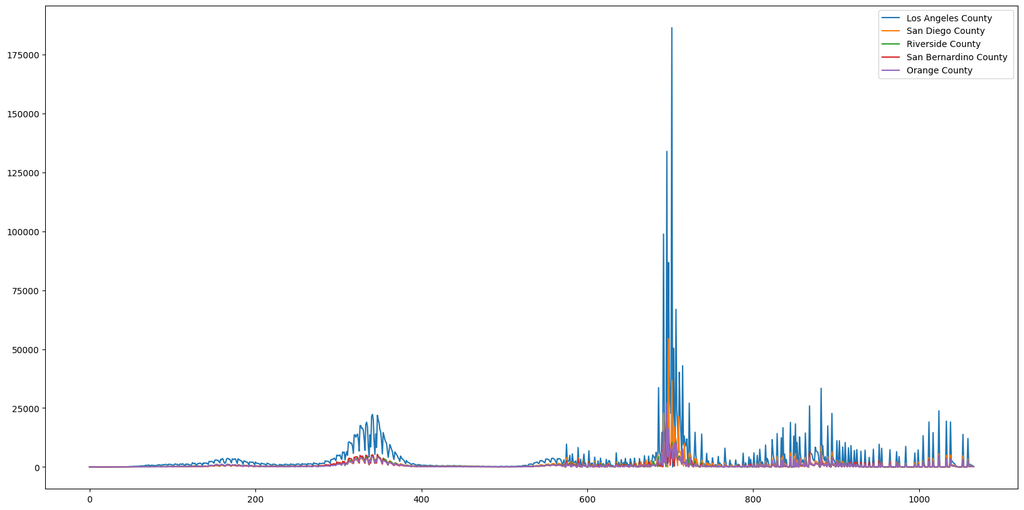

```python
covid_county_most_cases.plot(figsize=(20,10))
```

#### Analysis

The above plot shows the comparison between the top 5 counties in the selected state in terms of new covid-19 cases along a specific timeframe

We can see that Los Angelos comes at first place with the highest number of new cases along the whole timeframe.

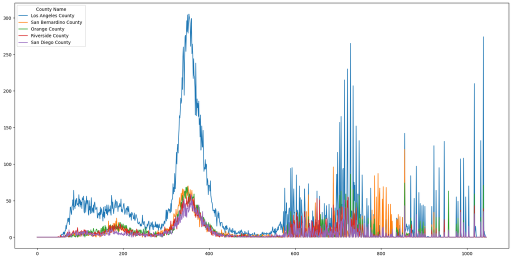

```python
covid_county_most_deaths.plot(figsize=(20,10))
```

```python
from sklearn import preprocessing, svm
from sklearn.model_selection import train_test_split
from sklearn.linear_model import LinearRegression
from sklearn.linear_model import LogisticRegression
from sklearn.metrics import mean_squared_error, mean_absolute_error
from sklearn.model_selection import train_test_split
from math import sqrt
import matplotlib.pyplot as plt
```

```python
x_cases = np.array(covid_state_most_cases.index).reshape(-1,1).astype(int)
y_cases = covid_state_most_cases.values.astype(int)
x_cases_train, x_cases_test, y_cases_train, y_cases_test = train_test_split(x_cases, y_cases, test_size = 0.15, shuffle=False)
lrl_cases = LinearRegression()
lrl_cases.fit(x_cases_train, y_cases_train)
y_pred_lrl_cases = lrl_cases.predict(x_cases_test)
rmse_lrl_cases = round(sqrt( mean_squared_error(y_cases_test, y_pred_lrl_cases)),2)
print(f'Linear regression Root Mean Square Error (RMSE): {rmse_lrl_cases}')
```

```
Linear regression Root Mean Square Error (RMSE): 11527.42
```

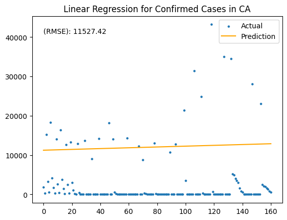

```python
plt.text(x=0,y=41000,s=f'(RMSE): {rmse_lrl_cases}')
plt.scatter(np.arange(len(y_cases_test)),y_cases_test, label='Actual', s=MARKER_SIZE)
plt.plot(y_pred_lrl_cases, color='orange', label='Prediction')
plt.legend()
plt.title(f'Linear Regression for Confirmed Cases in {selected_state_name}')
```

```python
lrg_cases = LogisticRegression()
lrg_cases.fit(x_cases_train,y_cases_train)
y_pred_cases_lrg = lrg_cases.predict(x_cases_test)
rmse_cases_lrg = round(sqrt( mean_squared_error(y_cases_test, y_pred_cases_lrg)),2)
print(f'Logestic regression Root Mean Square Error (RMSE): {rmse_cases_lrg}')
```

```
Logestic regression Root Mean Square Error (RMSE): 8376.57
```

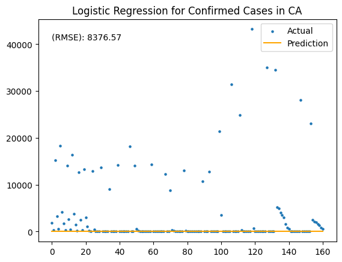

```python
plt.title(f'Logistic Regression for Confirmed Cases in {selected_state_name}')
plt.text(x=0,y=41000,s=f'(RMSE): {rmse_cases_lrg}')
plt.scatter(np.arange(len(y_cases_test)),y_cases_test,label='Actual',s=MARKER_SIZE)
plt.plot(y_pred_cases_lrg, color='orange', label='Prediction', scaley='log')
plt.legend()
```

```python
model_1 = MyRegressionModel(x_cases_train, y_cases_train, x_cases_test, y_cases_test, fit_type='Polynomial', error_type='RMSE', degree=3)
```

```
       prediction         upper         lower
0    10233.316425  30996.166551 -10529.533701
1    10241.279906  31004.130032 -10521.570220
2    10249.267400  31012.117526 -10513.582727
3    10257.279013  31020.129139 -10505.571114
4    10265.314852  31028.164978 -10497.535274
..            ...           ...           ...
156  11832.226156  32595.076283  -8930.623970
157  11845.227049  32608.077176  -8917.623077
158  11858.268619  32621.118745  -8904.581507
159  11871.350972  32634.201098  -8891.499155
160  11884.474214  32647.324341  -8878.375912

[161 rows x 3 columns]
```

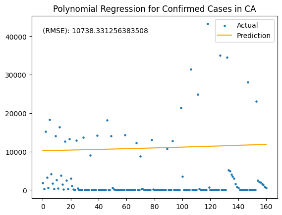

```python
plt.title(f'Polynomial Regression for Confirmed Cases in {selected_state_name}')
plt.text(x=0,y=41000,s=f'(RMSE): {model_1.error}')
plt.scatter(np.arange(len(y_cases_test)),y_cases_test,label='Actual',s=MARKER_SIZE)
plt.plot(model_1.predict(x_cases_test), color='orange', label='Prediction', scaley='log')
plt.legend()
```

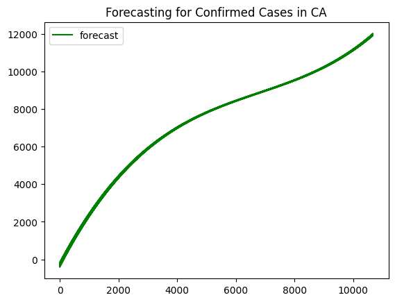

```python
plt.title(f'Forecasting for Confirmed Cases in {selected_state_name}')
x_forecast = x_cases + [np.arange(FORECAST_IN_DAYS)]
plt.plot(model_1.predict(x_forecast.reshape(-1,1)), color='green', label='forecast')
```

```python
x_deaths = np.array(covid_state_most_deaths.index).reshape(-1,1).astype(int)
y_deaths = covid_state_most_deaths.values.astype(int)
x_deaths_train, x_deaths_test, y_deaths_train, y_deaths_test = train_test_split(x_deaths, y_deaths, test_size = 0.15, shuffle=False)
lrl_deaths = LinearRegression()
lrl_deaths.fit(x_deaths_train, y_deaths_train)
y_pred_lrl_deaths = lrl_deaths.predict(x_deaths_test)
rmse_lrl_deaths = sqrt( mean_squared_error(y_deaths_test, y_pred_lrl_deaths))
print(f'Linear regression Root Mean Square Error (RMSE): {round(rmse_lrl_deaths,2)}')
```

```
Linear regression Root Mean Square Error (RMSE): 67.12
```

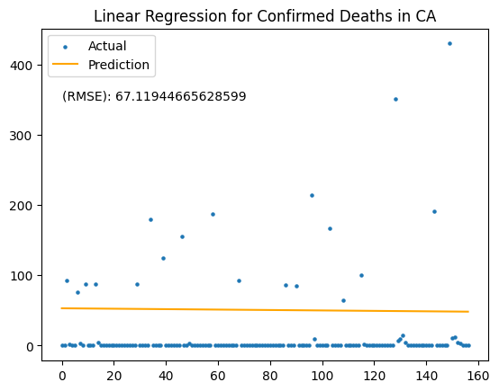

```python
plt.scatter(np.arange(len(y_deaths_test)),y_deaths_test, label='Actual',s=MARKER_SIZE)
plt.plot(y_pred_lrl_deaths, color='orange', label='Prediction')
plt.legend()
plt.title('Linear Regression for Confirmed Deaths in ' + selected_state_name)
plt.text(x=0, y=350, s=f'(RMSE): {rmse_lrl_deaths}')
```

```python
lrg_deaths = LogisticRegression()
lrg_deaths.fit(x_deaths_train,y_deaths_train)
y_pred_deaths_lrg = lrg_deaths.predict(x_deaths_test)
rmse_deaths_lrg = round(sqrt( mean_squared_error(y_deaths_test, y_pred_deaths_lrg)),2)
print(f'Logestic regression Root Mean Square Error (RMSE): {rmse_deaths_lrg}')
```

```
Logestic regression Root Mean Square Error (RMSE): 61.89
```

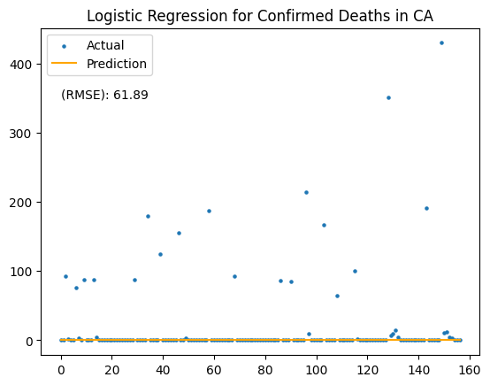

```python
plt.title(f'Logistic Regression for Confirmed Deaths in {selected_state_name}')
plt.text(x=0,y=350,s=f'(RMSE): {rmse_deaths_lrg}')
plt.scatter(np.arange(len(y_deaths_test)),y_deaths_test,label='Actual',s=MARKER_SIZE)
plt.plot(y_pred_deaths_lrg, color='orange', label='Prediction', scaley='log')
plt.legend()
```

```python
model_2 = MyRegressionModel(x_deaths_train, y_deaths_train, x_deaths_test, y_deaths_test, fit_type='Polynomial', error_type='RMSE', degree=3)
```

```
     prediction       upper       lower
0     51.411253  276.110670 -173.288165
1     51.780375  276.479793 -172.919042
2     52.153165  276.852583 -172.546253
3     52.529632  277.229050 -172.169786
4     52.909786  277.609204 -171.789631
..          ...         ...         ...
152  155.536573  380.235991  -69.162844
153  156.581817  381.281235  -68.117601
154  157.632301  382.331718  -67.067117
155  158.688035  383.387452  -66.011383
156  159.749029  384.448447  -64.950389

[157 rows x 3 columns]
```

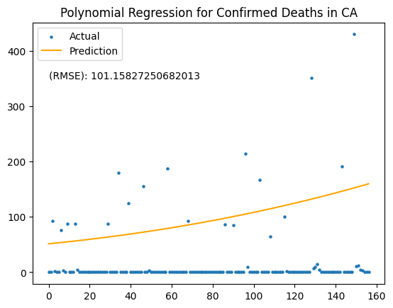

```python
plt.scatter(np.arange(len(y_deaths_test)),y_deaths_test, s=MARKER_SIZE)
plt.plot(model_2.predict(x_deaths_test), color='orange')
plt.text(x=0,y=350,s=f'(RMSE): {model_2.error}')
plt.title(f'Polynomial Regression for Confirmed Deaths in {selected_state_name}')
plt.legend(['Actual', 'Prediction'])
```

```python
x_county_1_cases = np.array(covid_county_1_most_cases.index).reshape(-1,1).astype(int)
x_county_2_cases = np.array(covid_county_2_most_cases.index).reshape(-1,1).astype(int)
x_county_3_cases = np.array(covid_county_3_most_cases.index).reshape(-1,1).astype(int)
x_county_4_cases = np.array(covid_county_4_most_cases.index).reshape(-1,1).astype(int)
x_county_5_cases = np.array(covid_county_5_most_cases.index).reshape(-1,1).astype(int)
y_county_1_cases = covid_county_1_most_cases.values.astype(int)
y_county_2_cases = covid_county_2_most_cases.values.astype(int)
y_county_3_cases = covid_county_3_most_cases.values.astype(int)
y_county_4_cases = covid_county_4_most_cases.values.astype(int)
y_county_5_cases = covid_county_5_most_cases.values.astype(int)
```

```python
x_county_1_cases_train, x_county_1_cases_test, y_county_1_cases_train, y_county_1_cases_test = train_test_split(x_county_1_cases, y_county_1_cases, test_size = 0.15, shuffle=False)
x_county_2_cases_train, x_county_2_cases_test, y_county_2_cases_train, y_county_2_cases_test = train_test_split(x_county_2_cases, y_county_2_cases, test_size = 0.15, shuffle=False)
x_county_3_cases_train, x_county_3_cases_test, y_county_3_cases_train, y_county_3_cases_test = train_test_split(x_county_3_cases, y_county_3_cases, test_size = 0.15, shuffle=False)
x_county_4_cases_train, x_county_4_cases_test, y_county_4_cases_train, y_county_4_cases_test = train_test_split(x_county_4_cases, y_county_4_cases, test_size = 0.15, shuffle=False)
x_county_5_cases_train, x_county_5_cases_test, y_county_5_cases_train, y_county_5_cases_test = train_test_split(x_county_5_cases, y_county_5_cases, test_size = 0.15, shuffle=False)
```

```python
lrl_county_1_cases = LinearRegression()
lrl_county_2_cases = LinearRegression()
lrl_county_3_cases = LinearRegression()
lrl_county_4_cases = LinearRegression()
lrl_county_5_cases = LinearRegression()
```

```python
lrl_county_1_cases.fit(x_county_1_cases_train, y_county_1_cases_train)
lrl_county_2_cases.fit(x_county_2_cases_train, y_county_2_cases_train)
lrl_county_3_cases.fit(x_county_3_cases_train, y_county_3_cases_train)
lrl_county_4_cases.fit(x_county_4_cases_train, y_county_4_cases_train)
lrl_county_5_cases.fit(x_county_5_cases_train, y_county_5_cases_train)
```

```
LinearRegression()
```

```python
y_pred_lrl_county_1_cases = lrl_county_1_cases.predict(x_county_1_cases_test)
y_pred_lrl_county_2_cases = lrl_county_2_cases.predict(x_county_2_cases_test)
y_pred_lrl_county_3_cases = lrl_county_3_cases.predict(x_county_3_cases_test)
y_pred_lrl_county_4_cases = lrl_county_4_cases.predict(x_county_4_cases_test)
y_pred_lrl_county_5_cases = lrl_county_5_cases.predict(x_county_5_cases_test)
```

```python
rmse_lrl_county_1_cases = round(sqrt( mean_squared_error(y_county_1_cases_test, y_pred_lrl_county_1_cases)),2)
rmse_lrl_county_2_cases = round(sqrt( mean_squared_error(y_county_2_cases_test, y_pred_lrl_county_2_cases)),2)
rmse_lrl_county_3_cases = round(sqrt( mean_squared_error(y_county_3_cases_test, y_pred_lrl_county_3_cases)),2)
rmse_lrl_county_4_cases = round(sqrt( mean_squared_error(y_county_4_cases_test, y_pred_lrl_county_4_cases)),2)
rmse_lrl_county_5_cases = round(sqrt( mean_squared_error(y_county_5_cases_test, y_pred_lrl_county_5_cases)),2)
```

```python
print(f'Linear regression Root Mean Square Error (RMSE): {selected_counties_most_cases_names[0]} \t\t {rmse_lrl_county_1_cases}')
print(f'Linear regression Root Mean Square Error (RMSE): {selected_counties_most_cases_names[1]} \t\t {rmse_lrl_county_2_cases}')
print(f'Linear regression Root Mean Square Error (RMSE): {selected_counties_most_cases_names[2]} \t\t {rmse_lrl_county_3_cases}')
print(f'Linear regression Root Mean Square Error (RMSE): {selected_counties_most_cases_names[3]} \t {rmse_lrl_county_4_cases}')
print(f'Linear regression Root Mean Square Error (RMSE): {selected_counties_most_cases_names[4]} \t\t {rmse_lrl_county_5_cases}')
```

```
Linear regression Root Mean Square Error (RMSE): Los Angeles County  		 6357.82
Linear regression Root Mean Square Error (RMSE): San Diego County  		 1852.23
Linear regression Root Mean Square Error (RMSE): Riverside County  		 1122.13
Linear regression Root Mean Square Error (RMSE): San Bernardino County  	 1101.61
Linear regression Root Mean Square Error (RMSE): Orange County  		 1156.27
```

```python
print(f'Confidence inteval for {selected_counties_most_cases_names[0]}')
model_3 = MyRegressionModel(x_county_1_cases_train, y_county_1_cases_train, x_county_1_cases_test, y_county_1_cases_test, fit_type='Polynomial')
print(f'Confidence inteval for {selected_counties_most_cases_names[1]}')
model_4 = MyRegressionModel(x_county_2_cases_train, y_county_2_cases_train, x_county_2_cases_test, y_county_2_cases_test, fit_type='Polynomial')
print(f'Confidence inteval for {selected_counties_most_cases_names[2]}')
model_5 = MyRegressionModel(x_county_3_cases_train, y_county_3_cases_train, x_county_3_cases_test, y_county_3_cases_test, fit_type='Polynomial')
print(f'Confidence inteval for {selected_counties_most_cases_names[3]}')
model_6 = MyRegressionModel(x_county_4_cases_train, y_county_4_cases_train, x_county_4_cases_test, y_county_4_cases_test, fit_type='Polynomial')
print(f'Confidence inteval for {selected_counties_most_cases_names[4]}')
model_7 = MyRegressionModel(x_county_5_cases_train, y_county_5_cases_train, x_county_5_cases_test, y_county_5_cases_test, fit_type='Polynomial')
```

```
Confidence inteval for Los Angeles County
      prediction         upper        lower
0    5516.090709  15980.126248 -4947.944831
1    5518.613980  15982.649519 -4945.421559
2    5521.135061  15985.170600 -4942.900479
3    5523.653968  15987.689507 -4940.381571
4    5526.170720  15990.206259 -4937.864819
..           ...           ...          ...
156  5894.336697  16358.372236 -4569.698843
157  5896.734505  16360.770044 -4567.301034
158  5899.132914  16363.168453 -4564.902625
159  5901.531941  16365.567480 -4562.503598
160  5903.931605  16367.967144 -4560.103935

[161 rows x 3 columns]
```

[output cut: 60 more lines]

```
RMSE: 5745.198930058755
```

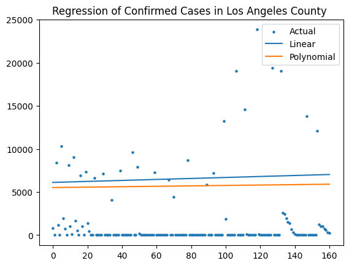

```python
plt.scatter(np.arange(len(y_county_1_cases_test)),y_county_1_cases_test, label=f'Actual', s=MARKER_SIZE)
plt.plot(y_pred_lrl_county_1_cases, label=f'Linear')
plt.plot(model_3.predict(x_county_1_cases_test), label=f'Polynomial')
plt.legend()
plt.title(f'Regression of Confirmed Cases in {selected_counties_most_cases_names[0]}')
print(f'RMSE: {model_3.error}')
```

```
RMSE: 1369.587334416514
```

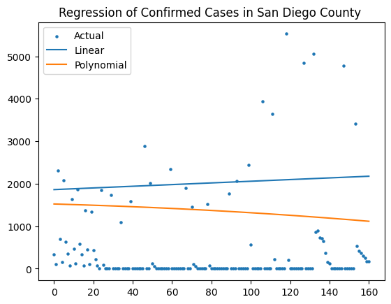

```python
plt.scatter(np.arange(len(y_county_2_cases_test)),y_county_2_cases_test, label=f'Actual', s=MARKER_SIZE)
plt.plot(y_pred_lrl_county_2_cases, label=f'Linear')
plt.plot(model_4.predict(x_county_2_cases_test), label=f'Polynomial')
plt.legend()
plt.title(f'Regression of Confirmed Cases in {selected_counties_most_cases_names[1]}')
print(f'RMSE: {model_4.error}')
```

```
RMSE: 1125.4924045873065
```

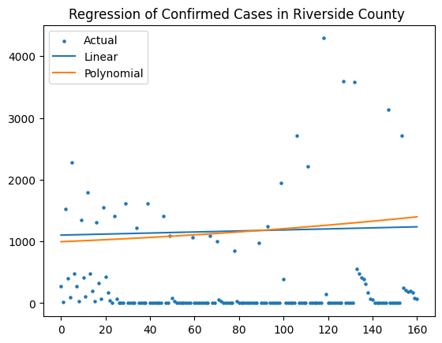

```python
plt.scatter(np.arange(len(y_county_3_cases_test)),y_county_3_cases_test, label=f'Actual', s=MARKER_SIZE)
plt.plot(y_pred_lrl_county_3_cases, label=f'Linear')
plt.plot(model_5.predict(x_county_3_cases_test), label=f'Polynomial')
plt.legend()
plt.title(f'Regression of Confirmed Cases in {selected_counties_most_cases_names[2]}')
print(f'RMSE: {model_5.error}')
```

```
RMSE: 1303.8920457810668
```

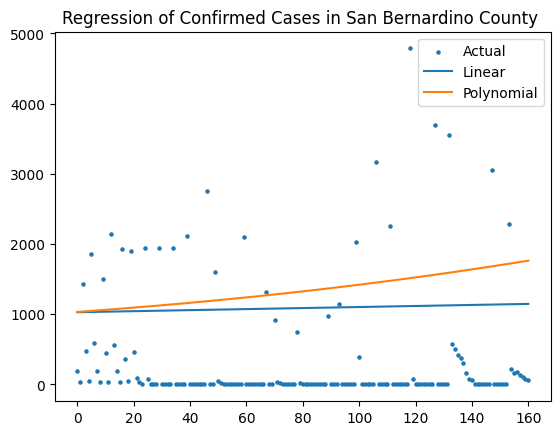

```python
plt.scatter(np.arange(len(y_county_4_cases_test)),y_county_4_cases_test, label=f'Actual', s=MARKER_SIZE)
plt.plot(y_pred_lrl_county_4_cases, label=f'Linear')
plt.plot(model_6.predict(x_county_4_cases_test), label=f'Polynomial')
plt.legend()
plt.title(f'Regression of Confirmed Cases in {selected_counties_most_cases_names[3]}')
print(f'RMSE: {model_6.error}')
```

```
RMSE: 1303.7670457212203
```

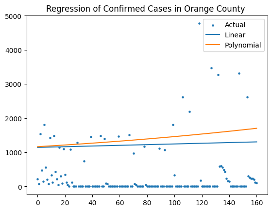

```python
plt.scatter(np.arange(len(y_county_5_cases_test)),y_county_5_cases_test, label=f'Actual', s=MARKER_SIZE)
plt.plot(y_pred_lrl_county_5_cases, label=f'Linear')
plt.plot(model_7.predict(x_county_5_cases_test), label=f'Polynomial')
plt.legend()
plt.title(f'Regression of Confirmed Cases in {selected_counties_most_cases_names[4]}')
print(f'RMSE: {model_7.error}')
```

### Observation

After doing the analysis and curve fitting on the counties mentioned above, we can see that for most of the counties numbers are on the rise, and even the forecasting of the models that we have says the same.

The most county at risk is Los Angelos, with the highest number in cases and deaths.

```python
enrichment_df = pd.read_csv(f'{PREFIX_PATH}enrichment.csv')
enrichment_df[enrichment_df.columns[3:]] = enrichment_df[enrichment_df.columns[3:]].apply(lambda x: x.str.strip('%').astype('float'))
enrichment_df = enrichment_df[enrichment_df['Sex'] == 'T']
enrichment_df = enrichment_df.drop(['Sex', 'StateFIPS'], axis=1)
enrichment_df = enrichment_df.set_index(enrichment_df['State']).drop('State', axis=1)
enrichment_df = enrichment_df.sort_index()
enrichment_youth_df = enrichment_df[enrichment_df.columns[:8]]
enrichment_senior_df = enrichment_df[enrichment_df.columns[8:]]
enrichment_youth_df = enrichment_youth_df.aggregate(np.sum, axis=1)
enrichment_senior_df = enrichment_senior_df.aggregate(np.sum, axis=1)
enrichment_df.head(3)
```

| State | Under 5 years | 5 to 9 years | 10 to 14 years | 15 to 19 years | 20 to 24 years | 25 to 29 years | 30 to 34 years | 35 to 39 years | 40 to 44 years | 45 to 49 years | 50 to 54 years | 55 to 59 years | 60 to 64 years | 65 to 69 years | 70 to 74 years | 75 to 79 years | 80 to 84 years | 85 years and over |
| --- | --- | --- | --- | --- | --- | --- | --- | --- | --- | --- | --- | --- | --- | --- | --- | --- | --- | --- |
| AK | 6.3 | 7.1 | 7.2 | 6.9 | 6.3 | 7.5 | 7.9 | 7.5 | 6.6 | 5.5 | 5.8 | 5.9 | 6.4 | 5.6 | 3.6 | 2.2 | 1.1 | 0.9 |
| AL | 5.8 | 5.9 | 6.7 | 6.7 | 6.4 | 6.2 | 6.3 | 6.2 | 6.5 | 6.0 | 6.3 | 6.6 | 6.8 | 5.8 | 4.9 | 3.2 | 2.1 | 1.6 |
| AR | 5.9 | 6.5 | 6.8 | 6.8 | 6.6 | 6.1 | 6.6 | 6.5 | 6.2 | 5.8 | 6.0 | 6.5 | 6.3 | 5.5 | 4.9 | 3.3 | 2.0 | 1.7 |

```python
covid_df = pd.read_csv(f'{PREFIX_PATH}covid_confirmed_usafacts.csv')
covid_df = covid_df[covid_df['countyFIPS'] != 0]
covid_df = covid_df.drop(['countyFIPS', 'County Name', 'StateFIPS'], axis=1)
covid_df = covid_df.groupby('State').sum()
covid_df = covid_df.transpose()
covid_df.index = pd.to_datetime(covid_df.index)
covid_df = covid_df.diff(axis=0)
covid_df = covid_df.drop(covid_df.index[0])
covid_df = covid_df.transpose()
covid_df = covid_df.sort_index()
covid_df = covid_df.groupby(covid_df.columns.isocalendar().week, axis=1).sum()
covid_df.head(3)
```

| week State | 1 | 2 | 3 | 4 | 5 | 6 | 7 | 8 | 9 | 10 | ... | 44 | 45 | 46 | 47 | 48 | 49 | 50 | 51 | 52 | 53 |
| --- | --- | --- | --- | --- | --- | --- | --- | --- | --- | --- | --- | --- | --- | --- | --- | --- | --- | --- | --- | --- | --- |
| AK | 10912.0 | 17935.0 | 16681.0 | 15817.0 | 10726.0 | 6468.0 | 4117.0 | 2724.0 | 2675.0 | 3185.0 | ... | 6834.0 | 5582.0 | 6529.0 | 6757.0 | 5861.0 | 6486.0 | 5689.0 | 4588.0 | 5750.0 | 2226.0 |
| AL | 109490.0 | 76397.0 | 134831.0 | 50737.0 | 100140.0 | 27598.0 | 17695.0 | 12873.0 | 11682.0 | 9903.0 | ... | 13620.0 | 19425.0 | 19153.0 | 20194.0 | 21974.0 | 32033.0 | 30726.0 | 50089.0 | 54155.0 | 26306.0 |
| AR | 61242.0 | 72275.0 | 67772.0 | 50398.0 | 33487.0 | 17345.0 | 10844.0 | 11038.0 | 6311.0 | 5483.0 | ... | 12383.0 | 14033.0 | 16697.0 | 16806.0 | 19344.0 | 23177.0 | 22754.0 | 24836.0 | 34645.0 | 18660.0 |

3 rows × 53 columns

```python
states_pop = pd.read_csv(f'{PREFIX_PATH}covid_county_population_usafacts.csv')
states_pop = states_pop[states_pop['countyFIPS'] != 0].drop(['countyFIPS', 'County Name'], axis=1).groupby('State', axis=0).sum().sort_index()
states_pop.head(3)
```

| State | population |
| --- | --- |
| AK | 731545 |
| AL | 4903185 |
| AR | 3017804 |

```python
covid_mean_df = covid_df.mean(axis=1).round()
covid_mean_normalized_df = covid_mean_df.divide(states_pop['population']) * NORMALIZATION_FACTOR
covid_mean_normalized_df = covid_mean_normalized_df.round()
covid_mean_normalized_df.head(3)
```

```
State
AK    720.0
AL    614.0
AR    597.0
dtype: float64
```

```python
covid_enrich_df = {'Cases': covid_mean_normalized_df, 'Youth':enrichment_youth_df, 'Senior':enrichment_senior_df}
covid_enrich_df = pd.concat(covid_enrich_df, axis=1).dropna()
covid_enrich_df.head(3)
```

| State | Cases | Youth | Senior |
| --- | --- | --- | --- |
| AK | 720.0 | 56.7 | 43.6 |
| AL | 614.0 | 50.2 | 49.8 |
| AR | 597.0 | 51.8 | 48.2 |

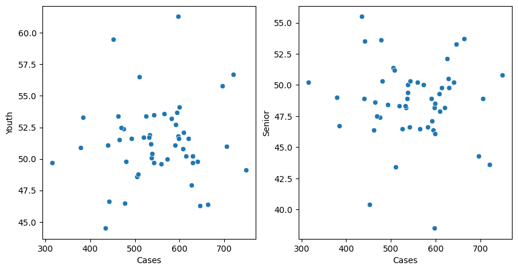

```python
import seaborn as sns

fig, ax = plt.subplots(1, 2, figsize=(10, 5))
sns.scatterplot(x=covid_enrich_df.Cases, y=covid_enrich_df.Youth, ax=ax[0])
sns.scatterplot(x=covid_enrich_df.Cases, y=covid_enrich_df.Senior, ax=ax[1])
```

```python
states_mean = covid_enrich_df.Cases.mean().round()
covid_youth_dom = covid_enrich_df[covid_enrich_df['Youth'] > 50].drop(['Youth', 'Senior'], axis=1)
```

#### Hypothesis Testing

##### Hypothesis #1:

- Hypothesis:
  - **Null Hypothesis H0** - Youth dominated states have similar new cases rate as the entire country
  - **Alternative Hypothesis H1** - Youth dominated states have different new cases rate from the entire country

```python
from scipy.stats import pearsonr
import scipy

covid_enrich_df['Youth'] = (covid_enrich_df['Youth']/50).astype(int)

corr, _ = pearsonr(covid_enrich_df.Cases.values, covid_enrich_df.Youth.values)
n = len(covid_enrich_df)
degrees_freedom = n - 1
r = corr

#calculate t-value
t = r * ((n - 2) / (1 - r**2))**0.5

#two tailed p-value
p = scipy.stats.t.sf(abs(t), degrees_freedom) * 2

print("Two-tailed t-test")
print("t-value:", t)
print("p-value:", p)

p1 = p/2
print("\nOne-tailed t-test")
print("p-value:", p1)
```

```
Two-tailed t-test
t-value: 0.15891566534075932
p-value: 0.8743754826126062

One-tailed t-test
p-value: 0.4371877413063031
```

- Results shows
  - The test statistic "t" is equal to 0.158
  - The PValue is 0.874 for the two tailed t-test
  - The PValue is 0.437 for the one tailed t-test
  - A high PValue shows that there is no significant difference between the population mean and the youth new cases mean

##### We should reject the Alternative Hypothesis H1